# Homework Chapter 7

Barret Miller

February 28, 2016

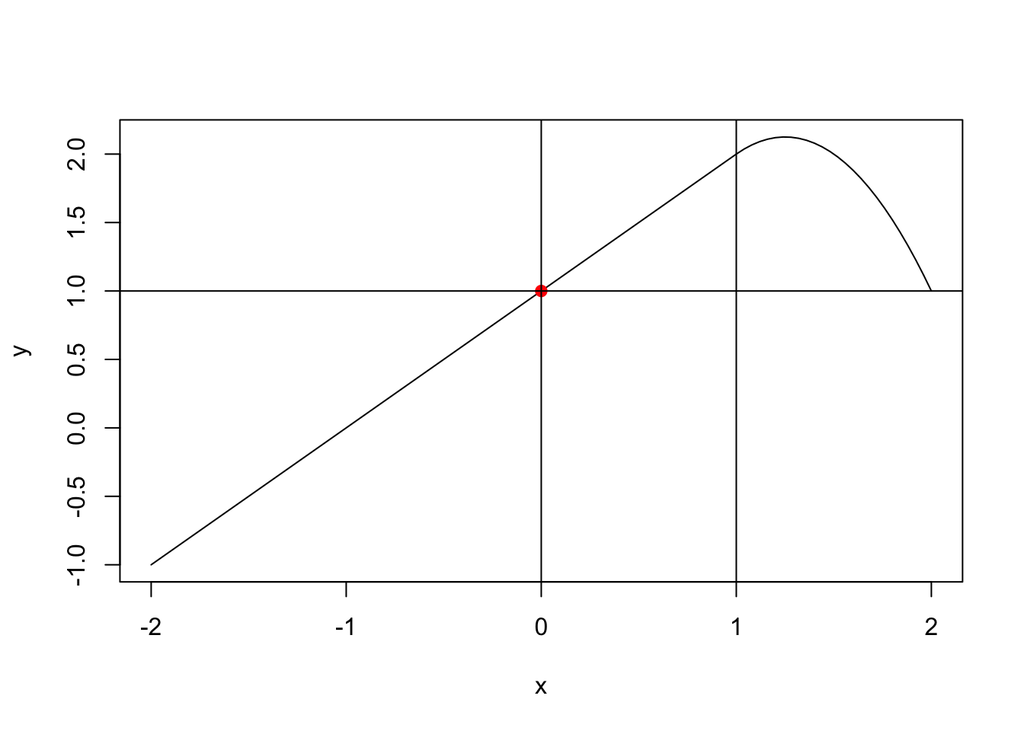

```r
par(mfrow=c(1,1))
y = function(x){
  1 + x + -2*(((x-1)^2)*I(x>=1))
}
plot(y,xlim=c(-2,2))
points(y=y(0),0,pch=19,col="red")
abline(v=0)
abline(h=1)
abline(v=1)
```

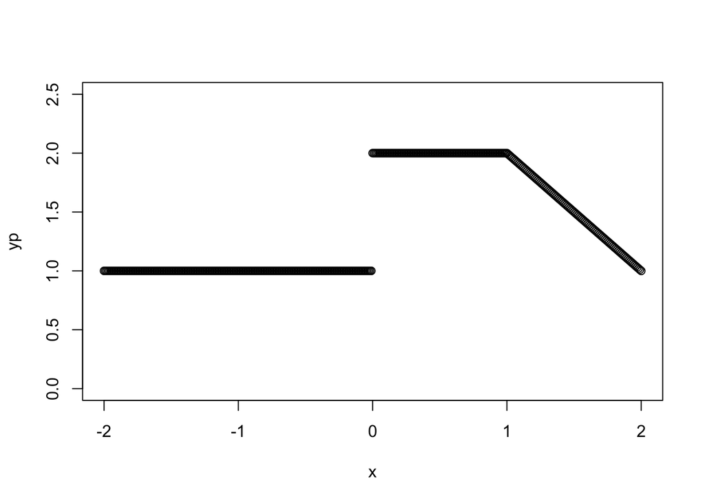

```r
y = function(x){
   # b1(X) = I(0 ≤ X ≤ 2) − (X −1)I(1 ≤ X ≤ 2)
   # b2(X) = (X −3)I(3 ≤ X ≤ 4)+I(4 < X ≤ 5)
   1 + (I(x>=0 && x<=2) - ((x-1)*I(x>=1 && x<=2))) + 3*((x-3)*I(x>=3 && x<=4) + I(x>4 && x<=5))
}
x=seq(-2,2,by=0.01)
yp = sapply(x,FUN=y)
plot(x,yp,xlim=c(-2,2),ylim=c(0,2.5))
```

```r
#points(x=x,y=y(x),pch=19,col="red")
```

Perform polynomial regression to predict wage using age. Use cross-validation to select the optimal degree d for the polyno- mial. What degree was chosen, and how does this compare to the results of hypothesis testing using ANOVA? Make a plot of the resulting polynomial fit to the data. Here, I will perform 10-fold cross validation to compare models with polynomials up to degree 5

```r
library(ISLR)
attach(Wage)

# Assign each observation a fold
set.seed(1)
folds = sample(1:10,size=nrow(Wage),replace=T)

# Check the distribution of fold assignment integers, make sure they are roughly even.
table(folds)
```

```
## folds
##   1   2   3   4   5   6   7   8   9  10
## 316 324 290 317 311 285 262 293 291 311
```

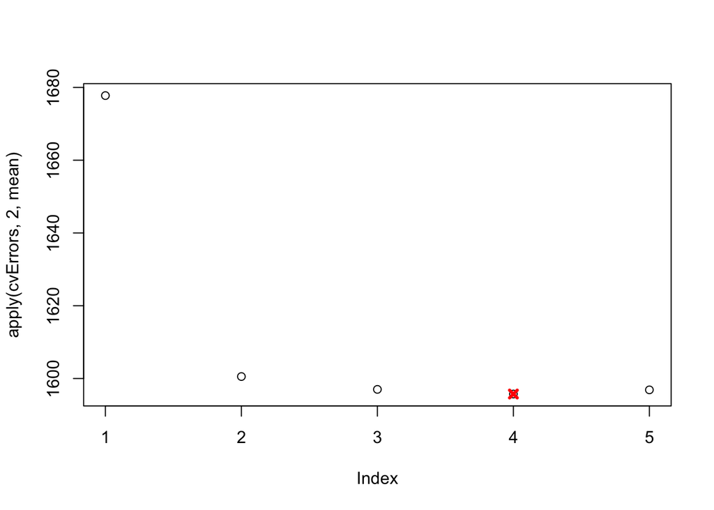

```r
# Set up a matrix which will have 1 row for every CV iteration. 1 column for polynomial degrees 1-5.
cvErrors = matrix(nrow=10,ncol=5)

# Loop over degrees of polynomial
for(d in 1:5){
   # Loop over folds of cv
   for(k in 1:10){
      fit=lm(wage~poly(age,d),data=Wage,subset=(folds!=k))
      preds=predict(fit,newdata=Wage[(folds==k),])
      cvErrors[k,d]=mean((preds-Wage[folds==k,c("wage")])^2)
   }
}

# Find which degree has lowest average MSE over all k folds:
plot(apply(cvErrors,2,mean))
bestPoly = which.min(apply(cvErrors,2,mean))
points(bestPoly,apply(cvErrors,2,mean)[bestPoly],pch=4,col="red",lwd=3)
```

The above plot shows that 4 is the best polynomial to use, but it doesn’t offer much improvement over 2 or three. In any case, we’ll still use 4 for now to fit the entire dataset, and then plot the dataset with the fit.

```r
bestFit = lm(wage~poly(age,bestPoly),data=Wage)
summary(bestFit)
```

```
##
## Call:
## lm(formula = wage ~ poly(age, bestPoly), data = Wage)
##
## Residuals:
##     Min      1Q  Median      3Q     Max
## -98.707 -24.626  -4.993  15.217 203.693
##
## Coefficients:
##                       Estimate Std. Error t value Pr(>|t|)
## (Intercept)           111.7036     0.7287 153.283  < 2e-16 ***
## poly(age, bestPoly)1  447.0679    39.9148  11.201  < 2e-16 ***
## poly(age, bestPoly)2 -478.3158    39.9148 -11.983  < 2e-16 ***
## poly(age, bestPoly)3  125.5217    39.9148   3.145  0.00168 **
## poly(age, bestPoly)4  -77.9112    39.9148  -1.952  0.05104 .
## ---
## Signif. codes:  0 '***' 0.001 '**' 0.01 '*' 0.05 '.' 0.1 ' ' 1
##
## Residual standard error: 39.91 on 2995 degrees of freedom
## Multiple R-squared:  0.08626,    Adjusted R-squared:  0.08504
## F-statistic: 70.69 on 4 and 2995 DF,  p-value: < 2.2e-16
```

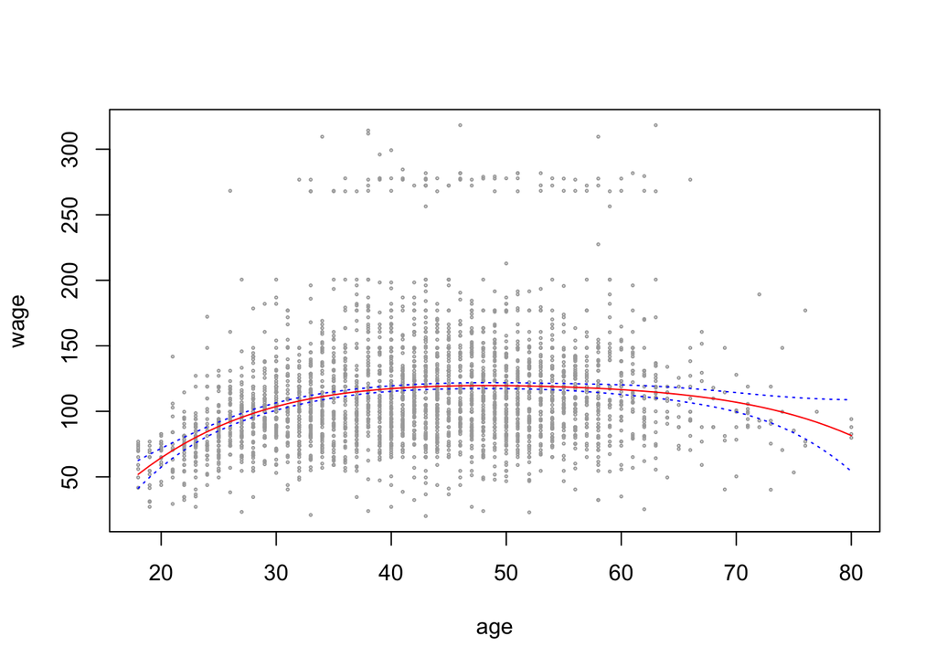

```r
plot(age,wage,xlim=range(age),ylim=range(wage),col="darkgrey",cex=.25)
ageXGrid = seq(range(age)[1],range(age)[2])
predsYFit = predict(bestFit,newdata=data.frame(age=ageXGrid),se=T)
seLines = cbind(predsYFit$fit + 2*predsYFit$se.fit,
                predsYFit$fit - 2*predsYFit$se.fit)
lines(ageXGrid,predsYFit$fit,col="red")
matlines(ageXGrid,seLines,col="blue",lty=3)
```

Since the built-in cut function seems to suck for some reason, I built my own. Notice how unbalanced the default cut function makes the data, despite the documentation, which states

> When breaks is specified as a single number, the range of the data is divided into breaks pieces of equal length, and then the outer limits are moved away by 0.1% of the range to ensure that the extreme values both fall within the break intervals.

```r
findCuts = function(v,n,warn=F) {
   if(n<2) return(NA)
   minVal = range(v)[1] - .1
   maxVal = range(v)[2] + .1
   internalCutIdx = seq(1:(n-1)) * floor(length(v)/n)
   internalCutVals = v[order(v)][internalCutIdx]

   fLen = length(internalCutVals)
   uLen = length(unique(internalCutVals))

   if(fLen != uLen && warn == T){
      warning(c("Internal break vector will be coerced from length ", fLen, " to length ", uLen,
                " to maintain uniqueness of breaks"))
   }
   #print(internalCutIdx)
   return(unique(c(minVal, internalCutVals, maxVal)))
}

table(cut(age,findCuts(age,2)))
```

```
##
## (17.9,42] (42,80.1]
##      1509      1491
```

```r
table(cut(age,2))
```

```
##
## (17.9,49] (49,80.1]
##      2149       851
```

Now we’ll use the cut function to create bins of dummy variables to break the continuous quantitative age variable up into a discrete set of categorical variables. We’ll do this for the entire range of x, and use cross validation to find the best cut of the data.

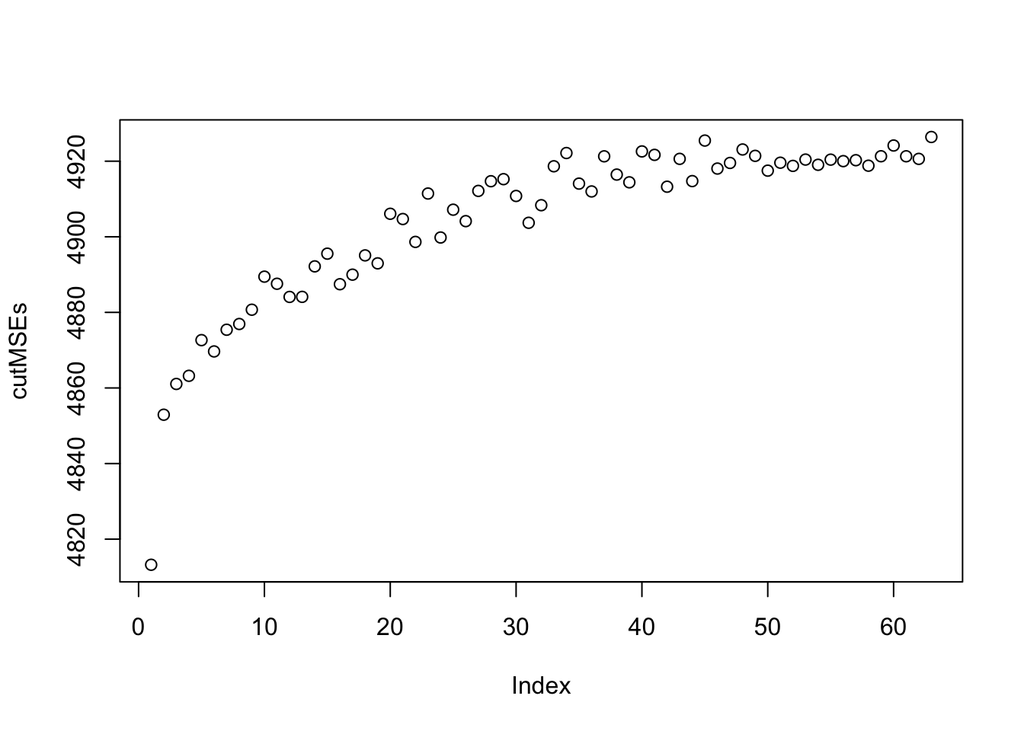

```r
ageGrid = seq(range(age)[1],range(age)[2])
cvErrors = matrix(nrow=10,ncol=length(ageGrid))

# Loop over all the cuts
for(c in 1:length(ageGrid)){
   # Cross validate for every k
   for(k in 1:10){
      if(c<2){
         fitck = lm(wage~age,data=Wage,subset=(folds!=k))
      }
      else{
         kCuts = findCuts(age[(folds!=k)],c)
         #print(paste0("Fitting cut ",c))
         #print(paste0("Fitting cut ",c," with breaks: ",paste0(kCuts,collapse=",")))
         fitck = lm(wage~cut(age,kCuts),data=Wage,subset=(folds!=k))
      }
      predsck = predict(fitck,newdata=Wage[(folds==k),])
      cvErrors[k,c] = mean((predsck-Wage[(folds==k),c("age")])^2)
   }
}



#Average the cvErrors for all the cuts:
cutMSEs = apply(cvErrors,2,mean)
plot(cutMSEs)
```

The above is not exactly what we want, I see after looking at the solution. What ends up happening with my above method is that each k training set and test set are cut separately using the same breaks, which are first found on the training set. A different set of breaks is found k times. Then, I predict on the test set using those cuts found on the training set. Each test set will be small compared to the training set, and will probably not have the same distribution of observations to cut bins. I don’t understand exactly what is happening, but after seeing the solution, it seems much better to add a cut field to the dataset before doing any cross validation. Also, the cv.glm would have made things much easier. Note: the below still does run into the same technical problem I was running into trying to compare cuts for the entire range of age: “Factor has new levels” at 31 cuts. I don’t see how the prediction set could have levels not in the training set, unless they were at the boundary, but these aren’t. Also, printing out the levels that get created by the cuts shows that this particular level seems to exist.

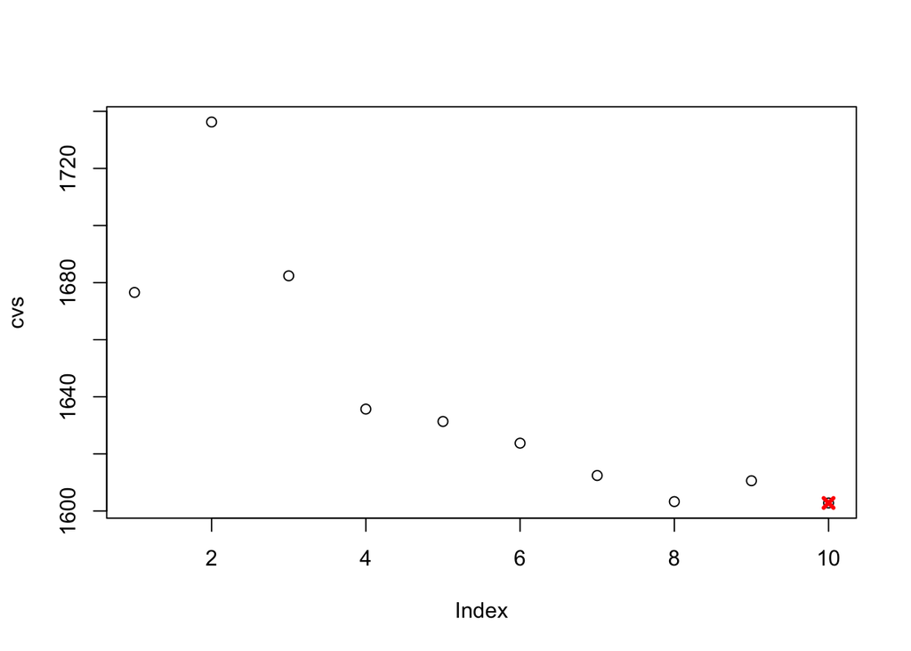

```r
library(boot)
cvs = rep(NA,10)
for(c in 1:10){
#for(c in 1:length(ageGrid)){
      #print(c)
      if(c<2){
         fitc = glm(wage~age,data=Wage)
      }
      else{
         Wage$ageCut <- cut(Wage$age,c)
         #print(levels(Wage$ageCut))
         fitc = glm(wage~ageCut,data=Wage)
      }

   cvs[c] = cv.glm(Wage,fitc,K=10)$delta[1]
}
bestCut = which.min(cvs)
plot(cvs)
points(bestCut, cvs[bestCut], pch=4, col="red",lwd=3)
```

Modeling it this way allows you to predict on age, but have the model transform the variable for you. The added benefit is that it’s easy to plot predictions vs. age.

```r
bestFit1 = glm(wage~cut(age, bestCut),data=Wage)
summary(bestFit1)
```

```
##
## Call:
## glm(formula = wage ~ cut(age, bestCut), data = Wage)
##
## Deviance Residuals:
##     Min       1Q   Median       3Q      Max
## -99.966  -24.791   -4.883   16.025  201.787
##
## Coefficients:
##                              Estimate Std. Error t value Pr(>|t|)
## (Intercept)                    73.344      3.024  24.253  < 2e-16 ***
## cut(age, bestCut)(24.2,30.4]   24.359      3.709   6.567 6.02e-11 ***
## cut(age, bestCut)(30.4,36.6]   35.441      3.570   9.929  < 2e-16 ***
## cut(age, bestCut)(36.6,42.8]   44.767      3.478  12.871  < 2e-16 ***
## cut(age, bestCut)(42.8,49]     46.707      3.413  13.687  < 2e-16 ***
## cut(age, bestCut)(49,55.2]     43.145      3.574  12.072  < 2e-16 ***
## cut(age, bestCut)(55.2,61.4]   46.389      3.882  11.948  < 2e-16 ***
## cut(age, bestCut)(61.4,67.6]   43.211      5.081   8.504  < 2e-16 ***
## cut(age, bestCut)(67.6,73.8]   23.271      7.796   2.985  0.00286 **
## cut(age, bestCut)(73.8,80.1]   21.217     11.500   1.845  0.06515 .
## ---
## Signif. codes:  0 '***' 0.001 '**' 0.01 '*' 0.05 '.' 0.1 ' ' 1
##
## (Dispersion parameter for gaussian family taken to be 1600.43)
##
##     Null deviance: 5222086  on 2999  degrees of freedom
## Residual deviance: 4785285  on 2990  degrees of freedom
## AIC: 30660
##
## Number of Fisher Scoring iterations: 2
```

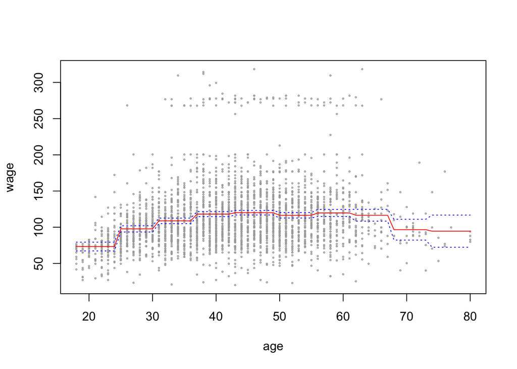

```r
plot(age,wage,xlim=range(age),ylim=range(wage),col="darkgrey",cex=.25)
predsYFit = predict(bestFit1,newdata=data.frame(age=ageXGrid),se=T)
seLines = cbind(predsYFit$fit + 2*predsYFit$se.fit,
                predsYFit$fit - 2*predsYFit$se.fit)
lines(ageXGrid,predsYFit$fit,col="red")
matlines(ageXGrid,seLines,col="blue",lty=3)
```

Modeling it this way, you need to know how to make it cut the same way. It becomes more difficult to plot the prediction vs. age, because this requires you to pass the cut to the model, instead of age to the model. The ultimate model is the same, but the way in which you pass arguments changes. Below, you can see a box plot of the now categorical variable of the age bins vs. the wage outcome, with predictions for each bin overlayed on top. You have to be careful with ordering the vectors to make sure they line up, but you can see that the predictions are close to the median for each cut, and within the inter-quartile range between the first and third quartiles.

```r
Wage$ageCut = cut(Wage$age,bestCut)
bestFit2 = glm(wage~ageCut,data=Wage)
summary(bestFit2)
```

```
##
## Call:
## glm(formula = wage ~ ageCut, data = Wage)
##
## Deviance Residuals:
##     Min       1Q   Median       3Q      Max
## -99.966  -24.791   -4.883   16.025  201.787
##
## Coefficients:
##                   Estimate Std. Error t value Pr(>|t|)
## (Intercept)         73.344      3.024  24.253  < 2e-16 ***
## ageCut(24.2,30.4]   24.359      3.709   6.567 6.02e-11 ***
## ageCut(30.4,36.6]   35.441      3.570   9.929  < 2e-16 ***
## ageCut(36.6,42.8]   44.767      3.478  12.871  < 2e-16 ***
## ageCut(42.8,49]     46.707      3.413  13.687  < 2e-16 ***
## ageCut(49,55.2]     43.145      3.574  12.072  < 2e-16 ***
## ageCut(55.2,61.4]   46.389      3.882  11.948  < 2e-16 ***
## ageCut(61.4,67.6]   43.211      5.081   8.504  < 2e-16 ***
## ageCut(67.6,73.8]   23.271      7.796   2.985  0.00286 **
## ageCut(73.8,80.1]   21.217     11.500   1.845  0.06515 .
## ---
## Signif. codes:  0 '***' 0.001 '**' 0.01 '*' 0.05 '.' 0.1 ' ' 1
##
## (Dispersion parameter for gaussian family taken to be 1600.43)
##
##     Null deviance: 5222086  on 2999  degrees of freedom
## Residual deviance: 4785285  on 2990  degrees of freedom
## AIC: 30660
##
## Number of Fisher Scoring iterations: 2
```

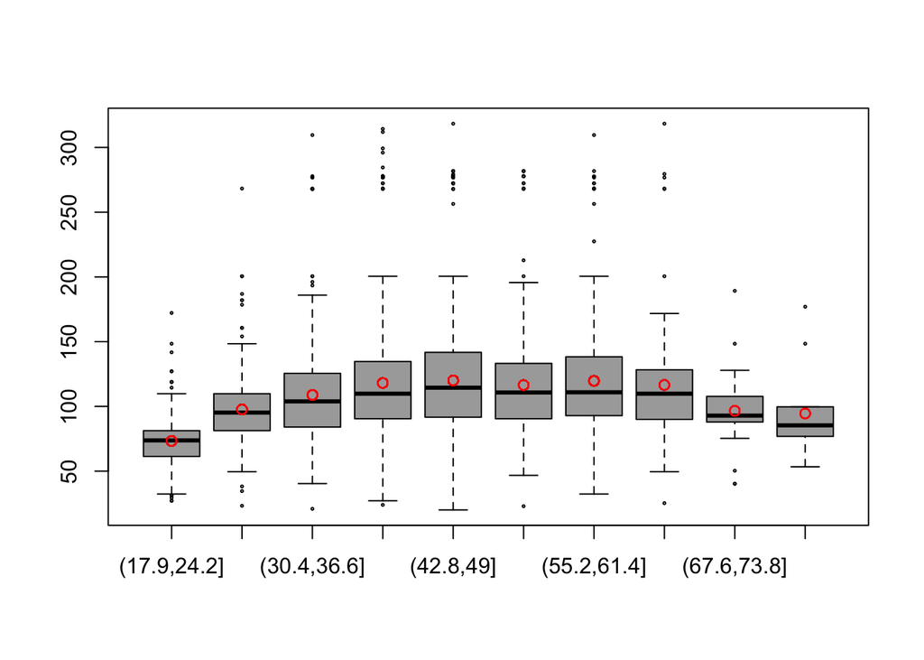

```r
plot(Wage$ageCut,wage,ylim=range(wage),col="darkgrey",cex=.25)
predsYFit = predict(bestFit2,newdata=data.frame(ageCut=Wage$ageCut[order(Wage$ageCut)]))
points(Wage$ageCut[order(Wage$ageCut)],predsYFit,col="red")
```